# Latent Class Analysis: Maternal Vulnerability Profiles and Birth Outcomes

Mary de Boer

2026-04-26

# Background

## Selected Risk Factor Indicators

The following indicators were: (a) theoretically associated with vulnerability to adverse birth outcomes based on a literature review, (b) seen to drive separation between classes when trial models were fit, and (c) available at the early pregnancy time period to allow for potential risk stratification.

All indicators were classified into two or three categories to permit LCA. The highest risk category was coded as “1.”

#### Individual indicators

- Age (<20, 20-35, >35 years)
- Woman’s Education (None, Some primary, Some secondary)

#### Nutritional indicators

- Height (<150cm, ≥150cm)
- BMI (underweight, normal, overweight)
- Early Pregnancy Anaemia (<11g/dL, ≥11g/dL)
- Early Pregnancy MDDW (<5 food groups, ≥5)

#### Household SES indicators

- Wealth Index (Lowest tertile, Middle, Highest)
- Husband’s Job (Unemployed/informal, Own business, Formal)
- Microcredit Use (No, Yes)

#### Other household indicators

- Husband’s Education (None, Some primary, Some secondary)
- Household Dependency Ratio (≥1, <1)
- Family Outside Household (No, Yes)
- Woman’s Daily Physical Labour (0 hours, 1-2 hours, >2 hours)

#### Pregnancy indicators

- Parity (0, 1, 2+)
- Previous Adverse Birth Outcome (Yes, No)
- High Risk Infection (UTI or LRI, Neither)

#### Psychosocial indicators

- Early Pregnancy Depression (Yes, No)
- Agency Scale (Lowest, Middle, Highest)
- Gender Norms (Lowest, Middle, Highest)

# Univariate Risk Factor Analysis

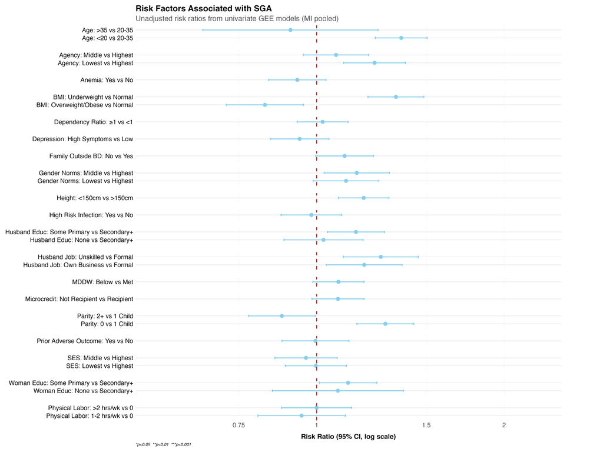

Unadjusted risk ratios from univariate GEE models with MI pooling

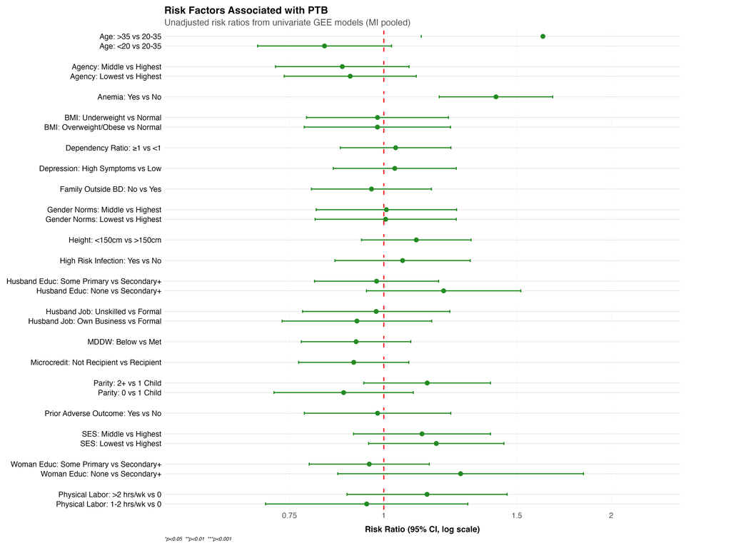

Unadjusted risk ratios from univariate GEE models with MI pooling

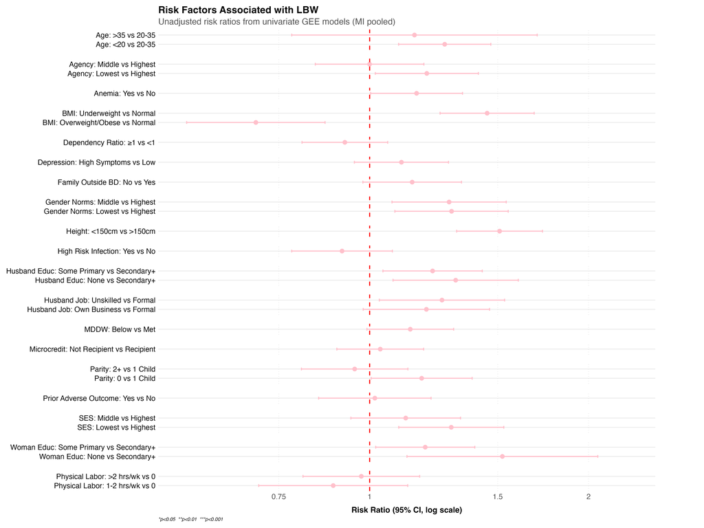

Unadjusted risk ratios from univariate GEE models with MI pooling

# Class Enumeration

## Model Fit Statistics

Model Fit Statistics by Number of Classes

| Classes | LogLik | AIC | BIC | SS_BIC | Entropy |
| --- | --- | --- | --- | --- | --- |
| 1 | -51180.2 | 102418.5 | 102596.0 | 102503.8 | NA |
| 2 | -49152.9 | 98423.9 | 98784.9 | 98597.5 | 0.779 |
| 3 | -48123.2 | 96424.3 | 96969.0 | 96686.2 | 0.855 |
| 4 | -47661.8 | 95561.5 | 96289.7 | 95911.6 | 0.872 |
| 5 | -47407.5 | 95113.0 | 96024.8 | 95551.4 | 0.851 |
| 6 | -47301.6 | 94961.1 | 96056.5 | 95487.7 | 0.791 |
| 7 | -47185.8 | 94789.7 | 96068.6 | 95404.5 | 0.808 |
| 8 | -47114.9 | 94707.8 | 96170.3 | 95410.9 | 0.798 |

Note: Selected model highlighted. SS-BIC = Sample Size Adjusted BIC.

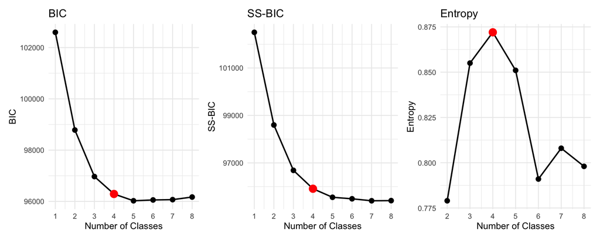

The four-class model was selected based on the elbow in BIC and SS-BIC curves and acceptable entropy, indicating good class separation.

## Classification Quality

Classification Quality: Average Posterior Probabilities and Odds of Correct Classification

| Class | N | Proportion | AvePP |
| --- | --- | --- | --- |
| Low-Risk Adequacy | 919 | 27.4% | 0.956 |
| High Parity & Undernutrition | 765 | 22.8% | 0.939 |
| Low Education & Poverty | 751 | 22.4% | 0.899 |
| Adolescent Low BMI | 924 | 27.5% | 0.932 |

Note: Overall pooled entropy: 0.871. AvePP > 0.70 indicates acceptable classification quality.

# Latent Class Profiles

## Class Line Plot

[figure not shown]

## Descriptive Statistics by Class

[output not shown]

# Adverse Birth Outcomes by Latent Class

## Prevalence Table

Prevalence (%, 95% CI) of Adverse Birth Outcomes by Latent Class

| Outcome | Low-Risk Adequacy (n=919) | High Parity & Undernutrition (n=765) | Low Education & Poverty (n=751) | Adolescent Low BMI (n=924) |
| --- | --- | --- | --- | --- |
| **Adverse Birth Outcomes** |  |  |  |  |
| SGA | 31.7 (28.4-34.9) | 48.1 (44.3-51.8) | 32.6 (29.0-36.2) | 39.0 (35.7-42.4) |
| PTB | 18.2 (15.5-20.9) | 13.2 (10.6-15.7) | 16.1 (13.3-18.9) | 15.8 (13.3-18.3) |
| LBW | 21.3 (18.4-24.2) | 27.5 (24.0-31.0) | 18.6 (15.6-21.7) | 25.5 (22.4-28.5) |
| Stillbirth | 2.7 (1.7-3.8) | 3.1 (1.9-4.4) | 0.9 (0.2-1.6) | 1.9 (1.1-2.8) |
| Any Adverse Outcome | 52.3 (48.8-55.8) | 64.5 (60.9-68.1) | 50.5 (46.6-54.3) | 57.3 (53.9-60.7) |
| PNM | 5.4 (3.8-6.9) | 5.6 (3.9-7.3) | 3.0 (1.7-4.3) | 3.8 (2.5-5.1) |
| NNM | 2.6 (1.5-3.7) | 2.5 (1.3-3.7) | 2.4 (1.3-3.6) | 2.1 (1.1-3.1) |
| **Birth Size/Gestational Age Categories** |  |  |  |  |
| AGA + Term | 43.0 (39.8-46.2) | 35.2 (31.8-38.5) | 46.2 (42.6-49.8) | 40.9 (37.7-44.1) |
| AGA + PTB | 14.6 (12.3-16.9) | 10.7 (8.5-12.9) | 12.8 (10.4-15.2) | 12.9 (10.7-15.0) |
| SGA + Term | 25.9 (23.1-28.7) | 41.6 (38.1-45.1) | 27.2 (24.0-30.3) | 33.3 (30.3-36.4) |
| SGA + PTB | 0.8 (0.2-1.3) | 0.9 (0.2-1.6) | 1.3 (0.5-2.2) | 1.1 (0.4-1.7) |

Note: Values are percentage (95% CI). AGA = Adequate for Gestational Age, LBW = Low Birth Weight, NNM = Neonatal Mortality, PNM = Perinatal Mortality, PTB = Pre-Term Birth, SGA = Small for Gestational Age.

# Regression Results

## Association of Latent Class with Adverse Birth Outcomes

Association of Latent Class with Adverse Birth Outcomes

| Outcome | Relative Risk (95% CI) High Parity & Undernutrition (n=765) | Relative Risk (95% CI) Low Education & Poverty (n=751) | Relative Risk (95% CI) Adolescent Low BMI (n=924) |
| --- | --- | --- | --- |
| **Adverse Birth Outcomes** |  |  |  |
| LBW | 1.3 (1.07-1.58)** | 0.81 (0.64-1.03)† | 1.21 (1-1.46)† |
| SGA | 1.56 (1.36-1.78)*** | 0.97 (0.82-1.14) | 1.23 (1.06-1.41)** |
| PTB | 0.71 (0.55-0.91)** | 0.93 (0.73-1.19) | 0.86 (0.68-1.08) |
| Stillbirth | 1.16 (0.66-2.04) | 0.32 (0.13-0.78)* | 0.67 (0.36-1.25) |
| Any Adverse Outcome | 1.26 (1.15-1.38)*** | 0.94 (0.84-1.05) | 1.09 (0.99-1.2)† |
| **Mortality** |  |  |  |
| PNM | 1.02 (0.66-1.58) | 0.52 (0.3-0.91)* | 0.68 (0.43-1.08) |
| NNM | 0.94 (0.48-1.84) | 0.88 (0.43-1.81) | 0.81 (0.42-1.56) |
| **Small Vulnerable Newborn Phenotypes** |  |  |  |
| SGA+PTB | 1.35 (0.45-4.08) | 1.57 (0.57-4.36) | 1.39 (0.51-3.79) |
| AGA+PTB | 0.93 (0.73-1.2) | 0.87 (0.68-1.11) | 0.92 (0.73-1.15) |
| SGA+Term | 1.48 (1.3-1.68)*** | 0.93 (0.79-1.09) | 1.18 (1.03-1.35)* |

Note: Reference class: Low-Risk Adequacy (n=919). Reference SVN Outcome: AGA+Term. GEE with exchangeable correlation structure, clustering by sector. Posterior probabilities used as continuous predictors. *p<0.05 **p<0.01*** p<0.001 †p<0.10

## Intervention Effects on Adverse Birth Outcomes

Intervention Effects on Adverse Birth Outcomes (Controlling for Latent Class)

| Outcome | Relative Risk (95% CI) Arm 2 vs 1 (n=835) | Relative Risk (95% CI) Arm 3 vs 1 (n=851) | Relative Risk (95% CI) Arm 4 vs 1 (n=868) |
| --- | --- | --- | --- |
| **Adverse Birth Outcomes** |  |  |  |
| LBW | 0.99 (0.82-1.2) | 1.04 (0.86-1.26) | 0.92 (0.76-1.12) |
| SGA | 0.97 (0.85-1.11) | 1.06 (0.94-1.21) | 0.95 (0.83-1.08) |
| PTB | 0.91 (0.72-1.14) | 0.78 (0.61-1)† | 1.02 (0.81-1.27) |
| Stillbirth | 2.09 (1-4.38)† | 1.89 (0.89-4)† | 2.02 (0.97-4.24)† |
| Any Adverse Outcome | 0.96 (0.88-1.05) | 0.99 (0.9-1.08) | 0.99 (0.9-1.08) |
| **Mortality** |  |  |  |
| PNM | 1.16 (0.73-1.86) | 0.96 (0.58-1.57) | 1.13 (0.71-1.81) |
| NNM | 0.71 (0.38-1.32) | 0.51 (0.25-1.02)† | 0.73 (0.4-1.35) |
| SGA+PTB | 0.6 (0.23-1.55) | 0.63 (0.25-1.62) | 0.76 (0.32-1.83) |
| AGA+PTB | 0.91 (0.72-1.15) | 0.84 (0.65-1.07) | 1 (0.8-1.25) |
| SGA+Term | 0.96 (0.85-1.09) | 1.04 (0.92-1.18) | 0.96 (0.84-1.09) |

Note: Reference: Arm 1 (Universal MMS, n=805). GEE with exchangeable correlation structure, clustering by sector. Controlling for latent class. * p<0.05 ** p<0.01 *** p<0.001 †p<0.10

## Treatment Effects on Primary Birth Outcomes by Latent Class

Treatment Effects on Primary Birth Outcomes by Latent Class of Maternal Vulnerability

| Outcome | Relative Risk (95% CI) Arm 2 vs 1 (n=835) | Relative Risk (95% CI) Arm 3 vs 1 (n=851) | Relative Risk (95% CI) Arm 4 vs 1 (n=868) |
| --- | --- | --- | --- |
| **Low-Risk Adequacy (n=919)** |  |  |  |
| SGA | 0.89 (0.64-1.23) | 1.25 (0.93-1.66) | 1.06 (0.79-1.44) |
| LBW | 0.77 (0.51-1.15) | 1.06 (0.74-1.51) | 0.7 (0.46-1.05)† |
| **High Parity & Undernutrition (n=765)** |  |  |  |
| SGA | 1.03 (0.83-1.28) | 0.94 (0.75-1.18) | 0.99 (0.79-1.23) |
| LBW | 0.97 (0.68-1.4) | 0.95 (0.66-1.38) | 1.14 (0.8-1.61) |
| **Low Education & Poverty (n=751)** |  |  |  |
| SGA | 0.85 (0.64-1.14) | 0.91 (0.68-1.22) | 0.67 (0.48-0.92)* |
| LBW | 1.14 (0.75-1.74) | 1.6 (0.71-3.6) | 0.53 (0.3-0.93)* |
| **Adolescent Low BMI (n=924)** |  |  |  |
| SGA | 1.07 (0.83-1.39) | 1.2 (0.94-1.52) | 1.07 (0.83-1.37) |
| LBW | 1.1 (0.77-1.57) | 1.01 (0.71-1.45) | 1.14 (0.81-1.62) |

Note:  
Reference: Arm 1 (Universal MMS, n=805)  
Arm 2 = Universal Balanced Energy Protein (BEP) supplementation  
Arm 3 = Targeted BEP for women with low BMI  
Arm 4 = Targeted BEP for women with low BMI and inadequate gestational weight gain  
SGA = Small for Gestational Age; LBW = Low Birth Weight  
* p<0.05; ** p<0.01; *** p<0.001; † p<0.10